# Risk Factor Analysis

## Outcome Variable

**Outcome Variable:** whz

## Predictor Variables

**Intervention Variable:** earlybf

**Adjustment Set:**

unadjusted

## Stratifying Variables

The analysis was stratified on these variable(s):

- agecat
- studyid
- country

## Data Summary

| agecat | studyid | country | earlybf | n_cell | n |
| --- | --- | --- | --- | --- | --- |
| Birth | ki0047075b-MAL-ED | BANGLADESH | 1 | 152 | 240 |
| Birth | ki0047075b-MAL-ED | BANGLADESH | 0 | 88 | 240 |
| Birth | ki0047075b-MAL-ED | BRAZIL | 1 | 79 | 183 |
| Birth | ki0047075b-MAL-ED | BRAZIL | 0 | 104 | 183 |
| Birth | ki0047075b-MAL-ED | INDIA | 1 | 123 | 202 |
| Birth | ki0047075b-MAL-ED | INDIA | 0 | 79 | 202 |
| Birth | ki0047075b-MAL-ED | NEPAL | 1 | 77 | 168 |
| Birth | ki0047075b-MAL-ED | NEPAL | 0 | 91 | 168 |
| Birth | ki0047075b-MAL-ED | PERU | 1 | 211 | 279 |
| Birth | ki0047075b-MAL-ED | PERU | 0 | 68 | 279 |
| Birth | ki0047075b-MAL-ED | SOUTH AFRICA | 1 | 154 | 245 |
| Birth | ki0047075b-MAL-ED | SOUTH AFRICA | 0 | 91 | 245 |
| Birth | ki0047075b-MAL-ED | TANZANIA, UNITED REPUBLIC OF | 1 | 108 | 118 |
| Birth | ki0047075b-MAL-ED | TANZANIA, UNITED REPUBLIC OF | 0 | 10 | 118 |
| Birth | ki1000109-EE | PAKISTAN | 1 | 1 | 1 |
| Birth | ki1000109-EE | PAKISTAN | 0 | 0 | 1 |
| Birth | ki1000304b-SAS-CompFeed | INDIA | 1 | 13 | 158 |
| Birth | ki1000304b-SAS-CompFeed | INDIA | 0 | 145 | 158 |
| Birth | ki1017093c-NIH-Crypto | BANGLADESH | 1 | 19 | 23 |
| Birth | ki1017093c-NIH-Crypto | BANGLADESH | 0 | 4 | 23 |
| Birth | ki1126311-ZVITAMBO | ZIMBABWE | 1 | 6141 | 11513 |
| Birth | ki1126311-ZVITAMBO | ZIMBABWE | 0 | 5372 | 11513 |
| Birth | kiGH5241-JiVitA-3 | BANGLADESH | 1 | 93 | 15648 |
| Birth | kiGH5241-JiVitA-3 | BANGLADESH | 0 | 15555 | 15648 |
| Birth | kiGH5241-JiVitA-4 | BANGLADESH | 1 | 475 | 683 |
| Birth | kiGH5241-JiVitA-4 | BANGLADESH | 0 | 208 | 683 |
| 6 months | ki0047075b-MAL-ED | BANGLADESH | 1 | 147 | 240 |
| 6 months | ki0047075b-MAL-ED | BANGLADESH | 0 | 93 | 240 |
| 6 months | ki0047075b-MAL-ED | BRAZIL | 1 | 95 | 209 |
| 6 months | ki0047075b-MAL-ED | BRAZIL | 0 | 114 | 209 |
| 6 months | ki0047075b-MAL-ED | INDIA | 1 | 140 | 236 |
| 6 months | ki0047075b-MAL-ED | INDIA | 0 | 96 | 236 |
| 6 months | ki0047075b-MAL-ED | NEPAL | 1 | 96 | 236 |
| 6 months | ki0047075b-MAL-ED | NEPAL | 0 | 140 | 236 |
| 6 months | ki0047075b-MAL-ED | PERU | 1 | 202 | 273 |
| 6 months | ki0047075b-MAL-ED | PERU | 0 | 71 | 273 |
| 6 months | ki0047075b-MAL-ED | SOUTH AFRICA | 1 | 156 | 250 |
| 6 months | ki0047075b-MAL-ED | SOUTH AFRICA | 0 | 94 | 250 |
| 6 months | ki0047075b-MAL-ED | TANZANIA, UNITED REPUBLIC OF | 1 | 205 | 247 |
| 6 months | ki0047075b-MAL-ED | TANZANIA, UNITED REPUBLIC OF | 0 | 42 | 247 |
| 6 months | ki1000109-EE | PAKISTAN | 1 | 69 | 376 |
| 6 months | ki1000109-EE | PAKISTAN | 0 | 307 | 376 |
| 6 months | ki1000304b-SAS-CompFeed | INDIA | 1 | 97 | 1334 |
| 6 months | ki1000304b-SAS-CompFeed | INDIA | 0 | 1237 | 1334 |
| 6 months | ki1017093c-NIH-Crypto | BANGLADESH | 1 | 619 | 715 |
| 6 months | ki1017093c-NIH-Crypto | BANGLADESH | 0 | 96 | 715 |
| 6 months | ki1113344-GMS-Nepal | NEPAL | 1 | 151 | 510 |
| 6 months | ki1113344-GMS-Nepal | NEPAL | 0 | 359 | 510 |
| 6 months | ki1126311-ZVITAMBO | ZIMBABWE | 1 | 3951 | 7339 |
| 6 months | ki1126311-ZVITAMBO | ZIMBABWE | 0 | 3388 | 7339 |
| 6 months | kiGH5241-JiVitA-3 | BANGLADESH | 1 | 36 | 16784 |
| 6 months | kiGH5241-JiVitA-3 | BANGLADESH | 0 | 16748 | 16784 |
| 6 months | kiGH5241-JiVitA-4 | BANGLADESH | 1 | 3095 | 4833 |
| 6 months | kiGH5241-JiVitA-4 | BANGLADESH | 0 | 1738 | 4833 |
| 24 months | ki0047075b-MAL-ED | BANGLADESH | 1 | 128 | 211 |
| 24 months | ki0047075b-MAL-ED | BANGLADESH | 0 | 83 | 211 |
| 24 months | ki0047075b-MAL-ED | BRAZIL | 1 | 80 | 169 |
| 24 months | ki0047075b-MAL-ED | BRAZIL | 0 | 89 | 169 |
| 24 months | ki0047075b-MAL-ED | INDIA | 1 | 134 | 227 |
| 24 months | ki0047075b-MAL-ED | INDIA | 0 | 93 | 227 |
| 24 months | ki0047075b-MAL-ED | NEPAL | 1 | 95 | 228 |
| 24 months | ki0047075b-MAL-ED | NEPAL | 0 | 133 | 228 |
| 24 months | ki0047075b-MAL-ED | PERU | 1 | 149 | 201 |
| 24 months | ki0047075b-MAL-ED | PERU | 0 | 52 | 201 |
| 24 months | ki0047075b-MAL-ED | SOUTH AFRICA | 1 | 144 | 235 |
| 24 months | ki0047075b-MAL-ED | SOUTH AFRICA | 0 | 91 | 235 |
| 24 months | ki0047075b-MAL-ED | TANZANIA, UNITED REPUBLIC OF | 1 | 180 | 214 |
| 24 months | ki0047075b-MAL-ED | TANZANIA, UNITED REPUBLIC OF | 0 | 34 | 214 |
| 24 months | ki1017093c-NIH-Crypto | BANGLADESH | 1 | 443 | 514 |
| 24 months | ki1017093c-NIH-Crypto | BANGLADESH | 0 | 71 | 514 |
| 24 months | ki1113344-GMS-Nepal | NEPAL | 1 | 136 | 454 |
| 24 months | ki1113344-GMS-Nepal | NEPAL | 0 | 318 | 454 |
| 24 months | ki1126311-ZVITAMBO | ZIMBABWE | 1 | 198 | 370 |
| 24 months | ki1126311-ZVITAMBO | ZIMBABWE | 0 | 172 | 370 |
| 24 months | kiGH5241-JiVitA-3 | BANGLADESH | 1 | 1 | 8603 |
| 24 months | kiGH5241-JiVitA-3 | BANGLADESH | 0 | 8602 | 8603 |
| 24 months | kiGH5241-JiVitA-4 | BANGLADESH | 1 | 3031 | 4735 |
| 24 months | kiGH5241-JiVitA-4 | BANGLADESH | 0 | 1704 | 4735 |

The following strata were considered:

- agecat: 24 months, studyid: ki0047075b-MAL-ED, country: BANGLADESH
- agecat: 24 months, studyid: ki0047075b-MAL-ED, country: BRAZIL
- agecat: 24 months, studyid: ki0047075b-MAL-ED, country: INDIA
- agecat: 24 months, studyid: ki0047075b-MAL-ED, country: NEPAL
- agecat: 24 months, studyid: ki0047075b-MAL-ED, country: PERU
- agecat: 24 months, studyid: ki0047075b-MAL-ED, country: SOUTH AFRICA
- agecat: 24 months, studyid: ki0047075b-MAL-ED, country: TANZANIA, UNITED REPUBLIC OF
- agecat: 24 months, studyid: ki1017093c-NIH-Crypto, country: BANGLADESH
- agecat: 24 months, studyid: ki1113344-GMS-Nepal, country: NEPAL
- agecat: 24 months, studyid: ki1126311-ZVITAMBO, country: ZIMBABWE
- agecat: 24 months, studyid: kiGH5241-JiVitA-3, country: BANGLADESH
- agecat: 24 months, studyid: kiGH5241-JiVitA-4, country: BANGLADESH
- agecat: 6 months, studyid: ki0047075b-MAL-ED, country: BANGLADESH
- agecat: 6 months, studyid: ki0047075b-MAL-ED, country: BRAZIL
- agecat: 6 months, studyid: ki0047075b-MAL-ED, country: INDIA
- agecat: 6 months, studyid: ki0047075b-MAL-ED, country: NEPAL
- agecat: 6 months, studyid: ki0047075b-MAL-ED, country: PERU
- agecat: 6 months, studyid: ki0047075b-MAL-ED, country: SOUTH AFRICA
- agecat: 6 months, studyid: ki0047075b-MAL-ED, country: TANZANIA, UNITED REPUBLIC OF
- agecat: 6 months, studyid: ki1000109-EE, country: PAKISTAN
- agecat: 6 months, studyid: ki1000304b-SAS-CompFeed, country: INDIA
- agecat: 6 months, studyid: ki1017093c-NIH-Crypto, country: BANGLADESH
- agecat: 6 months, studyid: ki1113344-GMS-Nepal, country: NEPAL
- agecat: 6 months, studyid: ki1126311-ZVITAMBO, country: ZIMBABWE
- agecat: 6 months, studyid: kiGH5241-JiVitA-3, country: BANGLADESH
- agecat: 6 months, studyid: kiGH5241-JiVitA-4, country: BANGLADESH
- agecat: Birth, studyid: ki0047075b-MAL-ED, country: BANGLADESH
- agecat: Birth, studyid: ki0047075b-MAL-ED, country: BRAZIL
- agecat: Birth, studyid: ki0047075b-MAL-ED, country: INDIA
- agecat: Birth, studyid: ki0047075b-MAL-ED, country: NEPAL
- agecat: Birth, studyid: ki0047075b-MAL-ED, country: PERU
- agecat: Birth, studyid: ki0047075b-MAL-ED, country: SOUTH AFRICA
- agecat: Birth, studyid: ki0047075b-MAL-ED, country: TANZANIA, UNITED REPUBLIC OF
- agecat: Birth, studyid: ki1000109-EE, country: PAKISTAN
- agecat: Birth, studyid: ki1000304b-SAS-CompFeed, country: INDIA
- agecat: Birth, studyid: ki1017093c-NIH-Crypto, country: BANGLADESH
- agecat: Birth, studyid: ki1126311-ZVITAMBO, country: ZIMBABWE
- agecat: Birth, studyid: kiGH5241-JiVitA-3, country: BANGLADESH
- agecat: Birth, studyid: kiGH5241-JiVitA-4, country: BANGLADESH

### Dropped Strata

Some strata were dropped due to rare outcomes:

- agecat: Birth, studyid: ki1000109-EE, country: PAKISTAN
- agecat: Birth, studyid: ki1017093c-NIH-Crypto, country: BANGLADESH
- agecat: 24 months, studyid: kiGH5241-JiVitA-3, country: BANGLADESH

## Methods Detail

We’re interested in the causal parameters $E[Y_a]$ for all values of $a \in \mathcal{A}$. These parameters represent the mean outcome if, possibly contrary to fact, we intervened to set all units to have $A=a$. Under the randomization and positivity assumptions, these are identified by the statistical parameters $\psi_a=E_W[E_{Y|A,W}(Y|A=a,W)]$. In addition, we’re interested in the mean of $Y$, $E[Y]$ under no intervention (the observed mean). We will estimate these parameters by using SuperLearner to fit the relevant likelihood factors – $E_{Y|A,W}(Y|A=a,W)$ and $p(A=a|W)$, and then updating our likelihood fit using a joint TMLE.

For unadjusted analyses ($W=\{\}$), initial likelihoods were estimated using Lrnr_glm to estimate the simple $E(Y|A)$ and Lrnr_mean to estimate $p(A)$. For adjusted analyses, a small library containing Lrnr_glmnet, Lrnr_xgboost, and Lrnr_mean was used.

Having estimated these parameters, we will then use the delta method to estimate relative risks and attributable risks relative to a prespecified baseline level of $A$.

# Results Detail

## Results Plots

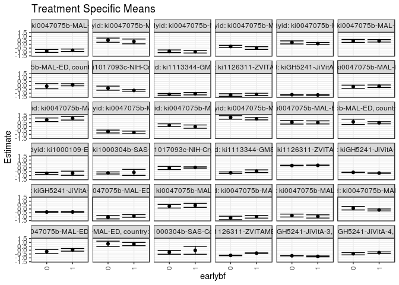

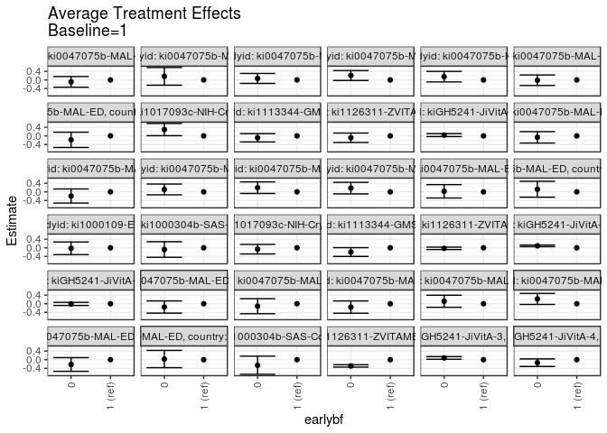

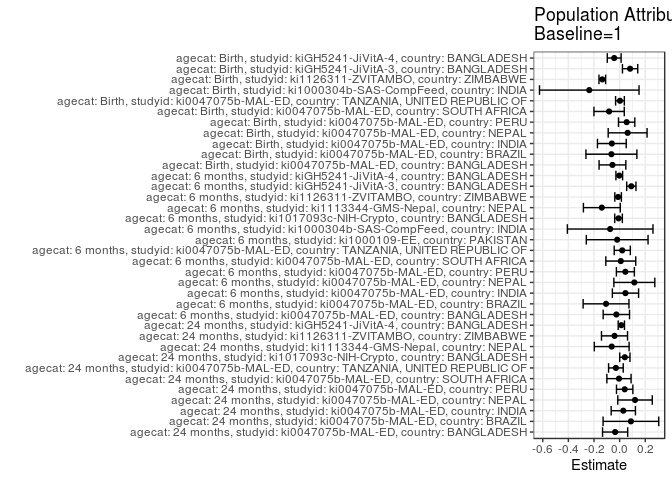

## Results Table

### Parameter: TSM

| agecat | studyid | country | intervention_level | baseline_level | estimate | ci_lower | ci_upper |
| --- | --- | --- | --- | --- | --- | --- | --- |
| Birth | ki0047075b-MAL-ED | BANGLADESH | 1 | NA | -0.9046053 | -1.0744300 | -0.7347805 |
| Birth | ki0047075b-MAL-ED | BANGLADESH | 0 | NA | -1.0575000 | -1.2845328 | -0.8304672 |
| Birth | ki0047075b-MAL-ED | BRAZIL | 1 | NA | 0.4681013 | 0.2092169 | 0.7269857 |
| Birth | ki0047075b-MAL-ED | BRAZIL | 0 | NA | 0.3550962 | 0.1202844 | 0.5899079 |
| Birth | ki0047075b-MAL-ED | INDIA | 1 | NA | -1.0045528 | -1.1811292 | -0.8279765 |
| Birth | ki0047075b-MAL-ED | INDIA | 0 | NA | -1.1601266 | -1.3847737 | -0.9354794 |
| Birth | ki0047075b-MAL-ED | NEPAL | 1 | NA | -0.9668831 | -1.1734215 | -0.7603447 |
| Birth | ki0047075b-MAL-ED | NEPAL | 0 | NA | -0.8516484 | -1.0401112 | -0.6631855 |
| Birth | ki0047075b-MAL-ED | PERU | 1 | NA | -0.1282938 | -0.2536390 | -0.0029487 |
| Birth | ki0047075b-MAL-ED | PERU | 0 | NA | 0.0961765 | -0.1283068 | 0.3206598 |
| Birth | ki0047075b-MAL-ED | SOUTH AFRICA | 1 | NA | 0.0407792 | -0.1308577 | 0.2124162 |
| Birth | ki0047075b-MAL-ED | SOUTH AFRICA | 0 | NA | -0.1807692 | -0.4469174 | 0.0853790 |
| Birth | ki0047075b-MAL-ED | TANZANIA, UNITED REPUBLIC OF | 1 | NA | 0.7906481 | 0.5777322 | 1.0035641 |
| Birth | ki0047075b-MAL-ED | TANZANIA, UNITED REPUBLIC OF | 0 | NA | 0.8210000 | 0.4808793 | 1.1611207 |
| Birth | ki1000304b-SAS-CompFeed | INDIA | 1 | NA | -0.0207692 | -0.5320631 | 0.4905247 |
| Birth | ki1000304b-SAS-CompFeed | INDIA | 0 | NA | -0.2790345 | -0.5298002 | -0.0282688 |
| Birth | ki1126311-ZVITAMBO | ZIMBABWE | 1 | NA | -0.3904429 | -0.4263433 | -0.3545425 |
| Birth | ki1126311-ZVITAMBO | ZIMBABWE | 0 | NA | -0.6805789 | -0.7225287 | -0.6386291 |
| Birth | kiGH5241-JiVitA-3 | BANGLADESH | 1 | NA | -0.8056989 | -0.8625792 | -0.7488186 |
| Birth | kiGH5241-JiVitA-3 | BANGLADESH | 0 | NA | -0.7236040 | -0.7439864 | -0.7032215 |
| Birth | kiGH5241-JiVitA-4 | BANGLADESH | 1 | NA | -0.3259158 | -0.4237279 | -0.2281037 |
| Birth | kiGH5241-JiVitA-4 | BANGLADESH | 0 | NA | -0.4651442 | -0.6100669 | -0.3202216 |
| 6 months | ki0047075b-MAL-ED | BANGLADESH | 1 | NA | -0.1080896 | -0.2725719 | 0.0563927 |
| 6 months | ki0047075b-MAL-ED | BANGLADESH | 0 | NA | -0.1743190 | -0.3822370 | 0.0335990 |
| 6 months | ki0047075b-MAL-ED | BRAZIL | 1 | NA | 1.0778596 | 0.8441615 | 1.3115578 |
| 6 months | ki0047075b-MAL-ED | BRAZIL | 0 | NA | 0.8832749 | 0.6546492 | 1.1119005 |
| 6 months | ki0047075b-MAL-ED | INDIA | 1 | NA | -0.7489405 | -0.9158423 | -0.5820386 |
| 6 months | ki0047075b-MAL-ED | INDIA | 0 | NA | -0.6369792 | -0.8242900 | -0.4496683 |
| 6 months | ki0047075b-MAL-ED | NEPAL | 1 | NA | -0.0036632 | -0.2142363 | 0.2069099 |
| 6 months | ki0047075b-MAL-ED | NEPAL | 0 | NA | 0.1897024 | 0.0231710 | 0.3562337 |
| 6 months | ki0047075b-MAL-ED | PERU | 1 | NA | 1.0095875 | 0.8660220 | 1.1531529 |
| 6 months | ki0047075b-MAL-ED | PERU | 0 | NA | 1.1818779 | 0.9561760 | 1.4075799 |
| 6 months | ki0047075b-MAL-ED | SOUTH AFRICA | 1 | NA | 0.5410470 | 0.3408758 | 0.7412182 |
| 6 months | ki0047075b-MAL-ED | SOUTH AFRICA | 0 | NA | 0.5646454 | 0.3272758 | 0.8020150 |
| 6 months | ki0047075b-MAL-ED | TANZANIA, UNITED REPUBLIC OF | 1 | NA | 0.4965610 | 0.3567538 | 0.6363682 |
| 6 months | ki0047075b-MAL-ED | TANZANIA, UNITED REPUBLIC OF | 0 | NA | 0.6170635 | 0.2761327 | 0.9579943 |
| 6 months | ki1000109-EE | PAKISTAN | 1 | NA | -0.7021014 | -0.9692347 | -0.4349682 |
| 6 months | ki1000109-EE | PAKISTAN | 0 | NA | -0.7255863 | -0.8508330 | -0.6003396 |
| 6 months | ki1000304b-SAS-CompFeed | INDIA | 1 | NA | -0.5918557 | -0.9793684 | -0.2043429 |
| 6 months | ki1000304b-SAS-CompFeed | INDIA | 0 | NA | -0.6714996 | -0.8053035 | -0.5376957 |
| 6 months | ki1017093c-NIH-Crypto | BANGLADESH | 1 | NA | 0.0384410 | -0.0470142 | 0.1238963 |
| 6 months | ki1017093c-NIH-Crypto | BANGLADESH | 0 | NA | -0.0261979 | -0.2307354 | 0.1783396 |
| 6 months | ki1113344-GMS-Nepal | NEPAL | 1 | NA | -0.4464901 | -0.6195454 | -0.2734347 |
| 6 months | ki1113344-GMS-Nepal | NEPAL | 0 | NA | -0.6438162 | -0.7516319 | -0.5360004 |
| 6 months | ki1126311-ZVITAMBO | ZIMBABWE | 1 | NA | 0.3141066 | 0.2769702 | 0.3512429 |
| 6 months | ki1126311-ZVITAMBO | ZIMBABWE | 0 | NA | 0.2881848 | 0.2466779 | 0.3296916 |
| 6 months | kiGH5241-JiVitA-3 | BANGLADESH | 1 | NA | -0.6847222 | -0.7154988 | -0.6539456 |
| 6 months | kiGH5241-JiVitA-3 | BANGLADESH | 0 | NA | -0.5933201 | -0.6133581 | -0.5732820 |
| 6 months | kiGH5241-JiVitA-4 | BANGLADESH | 1 | NA | -0.3869144 | -0.4315517 | -0.3422771 |
| 6 months | kiGH5241-JiVitA-4 | BANGLADESH | 0 | NA | -0.3949540 | -0.4555799 | -0.3343281 |
| 24 months | ki0047075b-MAL-ED | BANGLADESH | 1 | NA | -0.7805078 | -0.9387736 | -0.6222420 |
| 24 months | ki0047075b-MAL-ED | BANGLADESH | 0 | NA | -0.8700000 | -1.0618609 | -0.6781391 |
| 24 months | ki0047075b-MAL-ED | BRAZIL | 1 | NA | 0.3586875 | 0.0485055 | 0.6688695 |
| 24 months | ki0047075b-MAL-ED | BRAZIL | 0 | NA | 0.5256742 | 0.2550475 | 0.7963009 |
| 24 months | ki0047075b-MAL-ED | INDIA | 1 | NA | -0.9808955 | -1.1360252 | -0.8257659 |
| 24 months | ki0047075b-MAL-ED | INDIA | 0 | NA | -0.9110753 | -1.0820064 | -0.7401442 |
| 24 months | ki0047075b-MAL-ED | NEPAL | 1 | NA | -0.4964737 | -0.6741153 | -0.3188320 |
| 24 months | ki0047075b-MAL-ED | NEPAL | 0 | NA | -0.2907143 | -0.4362552 | -0.1451733 |
| 24 months | ki0047075b-MAL-ED | PERU | 1 | NA | 0.0805369 | -0.0655905 | 0.2266643 |
| 24 months | ki0047075b-MAL-ED | PERU | 0 | NA | 0.2326923 | 0.0369323 | 0.4284524 |
| 24 months | ki0047075b-MAL-ED | SOUTH AFRICA | 1 | NA | 0.4384028 | 0.2809879 | 0.5958177 |
| 24 months | ki0047075b-MAL-ED | SOUTH AFRICA | 0 | NA | 0.4249451 | 0.2383999 | 0.6114902 |
| 24 months | ki0047075b-MAL-ED | TANZANIA, UNITED REPUBLIC OF | 1 | NA | 0.0791667 | -0.0553653 | 0.2136986 |
| 24 months | ki0047075b-MAL-ED | TANZANIA, UNITED REPUBLIC OF | 0 | NA | -0.1038235 | -0.4320147 | 0.2243676 |
| 24 months | ki1017093c-NIH-Crypto | BANGLADESH | 1 | NA | -0.6509029 | -0.7516783 | -0.5501275 |
| 24 months | ki1017093c-NIH-Crypto | BANGLADESH | 0 | NA | -0.3573239 | -0.6224217 | -0.0922262 |
| 24 months | ki1113344-GMS-Nepal | NEPAL | 1 | NA | -1.0679779 | -1.2265573 | -0.9093986 |
| 24 months | ki1113344-GMS-Nepal | NEPAL | 0 | NA | -1.1563365 | -1.2676621 | -1.0450108 |
| 24 months | ki1126311-ZVITAMBO | ZIMBABWE | 1 | NA | -1.1563131 | -1.3000805 | -1.0125458 |
| 24 months | ki1126311-ZVITAMBO | ZIMBABWE | 0 | NA | -1.2425000 | -1.4069499 | -1.0780501 |
| 24 months | kiGH5241-JiVitA-4 | BANGLADESH | 1 | NA | -1.2363114 | -1.2766924 | -1.1959305 |
| 24 months | kiGH5241-JiVitA-4 | BANGLADESH | 0 | NA | -1.1996244 | -1.2534727 | -1.1457761 |

### Parameter: E(Y)

| agecat | studyid | country | intervention_level | baseline_level | estimate | ci_lower | ci_upper |
| --- | --- | --- | --- | --- | --- | --- | --- |
| Birth | ki0047075b-MAL-ED | BANGLADESH | NA | NA | -0.9606667 | -1.0969945 | -0.8243389 |
| Birth | ki0047075b-MAL-ED | BRAZIL | NA | NA | 0.4038798 | 0.2296279 | 0.5781316 |
| Birth | ki0047075b-MAL-ED | INDIA | NA | NA | -1.0653960 | -1.2046419 | -0.9261502 |
| Birth | ki0047075b-MAL-ED | NEPAL | NA | NA | -0.9044643 | -1.0439568 | -0.7649718 |
| Birth | ki0047075b-MAL-ED | PERU | NA | NA | -0.0735842 | -0.1836203 | 0.0364518 |
| Birth | ki0047075b-MAL-ED | SOUTH AFRICA | NA | NA | -0.0415102 | -0.1884529 | 0.1054324 |
| Birth | ki0047075b-MAL-ED | TANZANIA, UNITED REPUBLIC OF | NA | NA | 0.7932203 | 0.5962220 | 0.9902187 |
| Birth | ki1000304b-SAS-CompFeed | INDIA | NA | NA | -0.2577848 | -0.5195618 | 0.0039922 |
| Birth | ki1126311-ZVITAMBO | ZIMBABWE | NA | NA | -0.5258212 | -0.5533316 | -0.4983109 |
| Birth | kiGH5241-JiVitA-3 | BANGLADESH | NA | NA | -0.7240919 | -0.7439633 | -0.7042204 |
| Birth | kiGH5241-JiVitA-4 | BANGLADESH | NA | NA | -0.3683163 | -0.4490504 | -0.2875821 |
| 6 months | ki0047075b-MAL-ED | BANGLADESH | NA | NA | -0.1337535 | -0.2628178 | -0.0046891 |
| 6 months | ki0047075b-MAL-ED | BRAZIL | NA | NA | 0.9717225 | 0.8073791 | 1.1360658 |
| 6 months | ki0047075b-MAL-ED | INDIA | NA | NA | -0.7033969 | -0.8285284 | -0.5782654 |
| 6 months | ki0047075b-MAL-ED | NEPAL | NA | NA | 0.1110452 | -0.0202712 | 0.2423616 |
| 6 months | ki0047075b-MAL-ED | PERU | NA | NA | 1.0543956 | 0.9326967 | 1.1760945 |
| 6 months | ki0047075b-MAL-ED | SOUTH AFRICA | NA | NA | 0.5499200 | 0.3963965 | 0.7034435 |
| 6 months | ki0047075b-MAL-ED | TANZANIA, UNITED REPUBLIC OF | NA | NA | 0.5170513 | 0.3872178 | 0.6468847 |
| 6 months | ki1000109-EE | PAKISTAN | NA | NA | -0.7212766 | -0.8346857 | -0.6078675 |
| 6 months | ki1000304b-SAS-CompFeed | INDIA | NA | NA | -0.6657084 | -0.8024377 | -0.5289791 |
| 6 months | ki1017093c-NIH-Crypto | BANGLADESH | NA | NA | 0.0297622 | -0.0491685 | 0.1086930 |
| 6 months | ki1113344-GMS-Nepal | NEPAL | NA | NA | -0.5853922 | -0.6772967 | -0.4934876 |
| 6 months | ki1126311-ZVITAMBO | ZIMBABWE | NA | NA | 0.3021399 | 0.2744461 | 0.3298338 |
| 6 months | kiGH5241-JiVitA-3 | BANGLADESH | NA | NA | -0.5935161 | -0.6130518 | -0.5739805 |
| 6 months | kiGH5241-JiVitA-4 | BANGLADESH | NA | NA | -0.3898055 | -0.4270507 | -0.3525603 |
| 24 months | ki0047075b-MAL-ED | BANGLADESH | NA | NA | -0.8157109 | -0.9379759 | -0.6934459 |
| 24 months | ki0047075b-MAL-ED | BRAZIL | NA | NA | 0.4466272 | 0.2416144 | 0.6516401 |
| 24 months | ki0047075b-MAL-ED | INDIA | NA | NA | -0.9522907 | -1.0676596 | -0.8369219 |
| 24 months | ki0047075b-MAL-ED | NEPAL | NA | NA | -0.3764474 | -0.4898516 | -0.2630431 |
| 24 months | ki0047075b-MAL-ED | PERU | NA | NA | 0.1199005 | -0.0000331 | 0.2398341 |
| 24 months | ki0047075b-MAL-ED | SOUTH AFRICA | NA | NA | 0.4331915 | 0.3126798 | 0.5537032 |
| 24 months | ki0047075b-MAL-ED | TANZANIA, UNITED REPUBLIC OF | NA | NA | 0.0500935 | -0.0748234 | 0.1750103 |
| 24 months | ki1017093c-NIH-Crypto | BANGLADESH | NA | NA | -0.6103502 | -0.7050157 | -0.5156847 |
| 24 months | ki1113344-GMS-Nepal | NEPAL | NA | NA | -1.1298678 | -1.2212513 | -1.0384844 |
| 24 months | ki1126311-ZVITAMBO | ZIMBABWE | NA | NA | -1.1963784 | -1.3049250 | -1.0878318 |
| 24 months | kiGH5241-JiVitA-4 | BANGLADESH | NA | NA | -1.2231088 | -1.2549632 | -1.1912543 |

### Parameter: ATE

| agecat | studyid | country | intervention_level | baseline_level | estimate | ci_lower | ci_upper |
| --- | --- | --- | --- | --- | --- | --- | --- |
| Birth | ki0047075b-MAL-ED | BANGLADESH | 1 | 1 | 0.0000000 | 0.0000000 | 0.0000000 |
| Birth | ki0047075b-MAL-ED | BANGLADESH | 0 | 1 | -0.1528947 | -0.4364161 | 0.1306266 |
| Birth | ki0047075b-MAL-ED | BRAZIL | 1 | 1 | 0.0000000 | 0.0000000 | 0.0000000 |
| Birth | ki0047075b-MAL-ED | BRAZIL | 0 | 1 | -0.1130051 | -0.4625157 | 0.2365055 |
| Birth | ki0047075b-MAL-ED | INDIA | 1 | 1 | 0.0000000 | 0.0000000 | 0.0000000 |
| Birth | ki0047075b-MAL-ED | INDIA | 0 | 1 | -0.1555737 | -0.4413106 | 0.1301631 |
| Birth | ki0047075b-MAL-ED | NEPAL | 1 | 1 | 0.0000000 | 0.0000000 | 0.0000000 |
| Birth | ki0047075b-MAL-ED | NEPAL | 0 | 1 | 0.1152348 | -0.1643656 | 0.3948351 |
| Birth | ki0047075b-MAL-ED | PERU | 1 | 1 | 0.0000000 | 0.0000000 | 0.0000000 |
| Birth | ki0047075b-MAL-ED | PERU | 0 | 1 | 0.2244703 | -0.0326370 | 0.4815776 |
| Birth | ki0047075b-MAL-ED | SOUTH AFRICA | 1 | 1 | 0.0000000 | 0.0000000 | 0.0000000 |
| Birth | ki0047075b-MAL-ED | SOUTH AFRICA | 0 | 1 | -0.2215485 | -0.5382409 | 0.0951440 |
| Birth | ki0047075b-MAL-ED | TANZANIA, UNITED REPUBLIC OF | 1 | 1 | 0.0000000 | 0.0000000 | 0.0000000 |
| Birth | ki0047075b-MAL-ED | TANZANIA, UNITED REPUBLIC OF | 0 | 1 | 0.0303519 | -0.3709153 | 0.4316190 |
| Birth | ki1000304b-SAS-CompFeed | INDIA | 1 | 1 | 0.0000000 | 0.0000000 | 0.0000000 |
| Birth | ki1000304b-SAS-CompFeed | INDIA | 0 | 1 | -0.2582653 | -0.6795655 | 0.1630350 |
| Birth | ki1126311-ZVITAMBO | ZIMBABWE | 1 | 1 | 0.0000000 | 0.0000000 | 0.0000000 |
| Birth | ki1126311-ZVITAMBO | ZIMBABWE | 0 | 1 | -0.2901360 | -0.3453504 | -0.2349216 |
| Birth | kiGH5241-JiVitA-3 | BANGLADESH | 1 | 1 | 0.0000000 | 0.0000000 | 0.0000000 |
| Birth | kiGH5241-JiVitA-3 | BANGLADESH | 0 | 1 | 0.0820949 | 0.0209257 | 0.1432642 |
| Birth | kiGH5241-JiVitA-4 | BANGLADESH | 1 | 1 | 0.0000000 | 0.0000000 | 0.0000000 |
| Birth | kiGH5241-JiVitA-4 | BANGLADESH | 0 | 1 | -0.1392284 | -0.3149814 | 0.0365245 |
| 6 months | ki0047075b-MAL-ED | BANGLADESH | 1 | 1 | 0.0000000 | 0.0000000 | 0.0000000 |
| 6 months | ki0047075b-MAL-ED | BANGLADESH | 0 | 1 | -0.0662294 | -0.3313413 | 0.1988825 |
| 6 months | ki0047075b-MAL-ED | BRAZIL | 1 | 1 | 0.0000000 | 0.0000000 | 0.0000000 |
| 6 months | ki0047075b-MAL-ED | BRAZIL | 0 | 1 | -0.1945848 | -0.5215167 | 0.1323472 |
| 6 months | ki0047075b-MAL-ED | INDIA | 1 | 1 | 0.0000000 | 0.0000000 | 0.0000000 |
| 6 months | ki0047075b-MAL-ED | INDIA | 0 | 1 | 0.1119613 | -0.1389203 | 0.3628429 |
| 6 months | ki0047075b-MAL-ED | NEPAL | 1 | 1 | 0.0000000 | 0.0000000 | 0.0000000 |
| 6 months | ki0047075b-MAL-ED | NEPAL | 0 | 1 | 0.1933656 | -0.0750999 | 0.4618311 |
| 6 months | ki0047075b-MAL-ED | PERU | 1 | 1 | 0.0000000 | 0.0000000 | 0.0000000 |
| 6 months | ki0047075b-MAL-ED | PERU | 0 | 1 | 0.1722905 | -0.0952024 | 0.4397833 |
| 6 months | ki0047075b-MAL-ED | SOUTH AFRICA | 1 | 1 | 0.0000000 | 0.0000000 | 0.0000000 |
| 6 months | ki0047075b-MAL-ED | SOUTH AFRICA | 0 | 1 | 0.0235984 | -0.2869058 | 0.3341025 |
| 6 months | ki0047075b-MAL-ED | TANZANIA, UNITED REPUBLIC OF | 1 | 1 | 0.0000000 | 0.0000000 | 0.0000000 |
| 6 months | ki0047075b-MAL-ED | TANZANIA, UNITED REPUBLIC OF | 0 | 1 | 0.1205025 | -0.2479807 | 0.4889857 |
| 6 months | ki1000109-EE | PAKISTAN | 1 | 1 | 0.0000000 | 0.0000000 | 0.0000000 |
| 6 months | ki1000109-EE | PAKISTAN | 0 | 1 | -0.0234849 | -0.3185220 | 0.2715522 |
| 6 months | ki1000304b-SAS-CompFeed | INDIA | 1 | 1 | 0.0000000 | 0.0000000 | 0.0000000 |
| 6 months | ki1000304b-SAS-CompFeed | INDIA | 0 | 1 | -0.0796439 | -0.4423738 | 0.2830860 |
| 6 months | ki1017093c-NIH-Crypto | BANGLADESH | 1 | 1 | 0.0000000 | 0.0000000 | 0.0000000 |
| 6 months | ki1017093c-NIH-Crypto | BANGLADESH | 0 | 1 | -0.0646390 | -0.2863103 | 0.1570324 |
| 6 months | ki1113344-GMS-Nepal | NEPAL | 1 | 1 | 0.0000000 | 0.0000000 | 0.0000000 |
| 6 months | ki1113344-GMS-Nepal | NEPAL | 0 | 1 | -0.1973261 | -0.4012191 | 0.0065670 |
| 6 months | ki1126311-ZVITAMBO | ZIMBABWE | 1 | 1 | 0.0000000 | 0.0000000 | 0.0000000 |
| 6 months | ki1126311-ZVITAMBO | ZIMBABWE | 0 | 1 | -0.0259218 | -0.0816167 | 0.0297732 |
| 6 months | kiGH5241-JiVitA-3 | BANGLADESH | 1 | 1 | 0.0000000 | 0.0000000 | 0.0000000 |
| 6 months | kiGH5241-JiVitA-3 | BANGLADESH | 0 | 1 | 0.0914021 | 0.0542966 | 0.1285077 |
| 6 months | kiGH5241-JiVitA-4 | BANGLADESH | 1 | 1 | 0.0000000 | 0.0000000 | 0.0000000 |
| 6 months | kiGH5241-JiVitA-4 | BANGLADESH | 0 | 1 | -0.0080396 | -0.0805364 | 0.0644572 |
| 24 months | ki0047075b-MAL-ED | BANGLADESH | 1 | 1 | 0.0000000 | 0.0000000 | 0.0000000 |
| 24 months | ki0047075b-MAL-ED | BANGLADESH | 0 | 1 | -0.0894922 | -0.3382063 | 0.1592219 |
| 24 months | ki0047075b-MAL-ED | BRAZIL | 1 | 1 | 0.0000000 | 0.0000000 | 0.0000000 |
| 24 months | ki0047075b-MAL-ED | BRAZIL | 0 | 1 | 0.1669867 | -0.2446584 | 0.5786317 |
| 24 months | ki0047075b-MAL-ED | INDIA | 1 | 1 | 0.0000000 | 0.0000000 | 0.0000000 |
| 24 months | ki0047075b-MAL-ED | INDIA | 0 | 1 | 0.0698203 | -0.1610101 | 0.3006506 |
| 24 months | ki0047075b-MAL-ED | NEPAL | 1 | 1 | 0.0000000 | 0.0000000 | 0.0000000 |
| 24 months | ki0047075b-MAL-ED | NEPAL | 0 | 1 | 0.2057594 | -0.0238897 | 0.4354085 |
| 24 months | ki0047075b-MAL-ED | PERU | 1 | 1 | 0.0000000 | 0.0000000 | 0.0000000 |
| 24 months | ki0047075b-MAL-ED | PERU | 0 | 1 | 0.1521554 | -0.0921297 | 0.3964405 |
| 24 months | ki0047075b-MAL-ED | SOUTH AFRICA | 1 | 1 | 0.0000000 | 0.0000000 | 0.0000000 |
| 24 months | ki0047075b-MAL-ED | SOUTH AFRICA | 0 | 1 | -0.0134577 | -0.2575449 | 0.2306294 |
| 24 months | ki0047075b-MAL-ED | TANZANIA, UNITED REPUBLIC OF | 1 | 1 | 0.0000000 | 0.0000000 | 0.0000000 |
| 24 months | ki0047075b-MAL-ED | TANZANIA, UNITED REPUBLIC OF | 0 | 1 | -0.1829902 | -0.5376848 | 0.1717044 |
| 24 months | ki1017093c-NIH-Crypto | BANGLADESH | 1 | 1 | 0.0000000 | 0.0000000 | 0.0000000 |
| 24 months | ki1017093c-NIH-Crypto | BANGLADESH | 0 | 1 | 0.2935790 | 0.0099727 | 0.5771853 |
| 24 months | ki1113344-GMS-Nepal | NEPAL | 1 | 1 | 0.0000000 | 0.0000000 | 0.0000000 |
| 24 months | ki1113344-GMS-Nepal | NEPAL | 0 | 1 | -0.0883585 | -0.2821131 | 0.1053960 |
| 24 months | ki1126311-ZVITAMBO | ZIMBABWE | 1 | 1 | 0.0000000 | 0.0000000 | 0.0000000 |
| 24 months | ki1126311-ZVITAMBO | ZIMBABWE | 0 | 1 | -0.0861869 | -0.3046195 | 0.1322457 |
| 24 months | kiGH5241-JiVitA-4 | BANGLADESH | 1 | 1 | 0.0000000 | 0.0000000 | 0.0000000 |
| 24 months | kiGH5241-JiVitA-4 | BANGLADESH | 0 | 1 | 0.0366870 | -0.0315334 | 0.1049075 |

### Parameter: PAR

| agecat | studyid | country | intervention_level | baseline_level | estimate | ci_lower | ci_upper |
| --- | --- | --- | --- | --- | --- | --- | --- |
| Birth | ki0047075b-MAL-ED | BANGLADESH | 1 | NA | -0.0560614 | -0.1604381 | 0.0483152 |
| Birth | ki0047075b-MAL-ED | BRAZIL | 1 | NA | -0.0642215 | -0.2630169 | 0.1345739 |
| Birth | ki0047075b-MAL-ED | INDIA | 1 | NA | -0.0608432 | -0.1730835 | 0.0513972 |
| Birth | ki0047075b-MAL-ED | NEPAL | 1 | NA | 0.0624188 | -0.0892815 | 0.2141192 |
| Birth | ki0047075b-MAL-ED | PERU | 1 | NA | 0.0547096 | -0.0089703 | 0.1183895 |
| Birth | ki0047075b-MAL-ED | SOUTH AFRICA | 1 | NA | -0.0822894 | -0.2006825 | 0.0361036 |
| Birth | ki0047075b-MAL-ED | TANZANIA, UNITED REPUBLIC OF | 1 | NA | 0.0025722 | -0.0314680 | 0.0366124 |
| Birth | ki1000304b-SAS-CompFeed | INDIA | 1 | NA | -0.2370156 | -0.6254097 | 0.1513785 |
| Birth | ki1126311-ZVITAMBO | ZIMBABWE | 1 | NA | -0.1353783 | -0.1612768 | -0.1094798 |
| Birth | kiGH5241-JiVitA-3 | BANGLADESH | 1 | NA | 0.0816070 | 0.0219665 | 0.1412476 |
| Birth | kiGH5241-JiVitA-4 | BANGLADESH | 1 | NA | -0.0424005 | -0.0964097 | 0.0116088 |
| 6 months | ki0047075b-MAL-ED | BANGLADESH | 1 | NA | -0.0256639 | -0.1284762 | 0.0771484 |
| 6 months | ki0047075b-MAL-ED | BRAZIL | 1 | NA | -0.1061372 | -0.2849491 | 0.0726748 |
| 6 months | ki0047075b-MAL-ED | INDIA | 1 | NA | 0.0455436 | -0.0567519 | 0.1478391 |
| 6 months | ki0047075b-MAL-ED | NEPAL | 1 | NA | 0.1147084 | -0.0450132 | 0.2744300 |
| 6 months | ki0047075b-MAL-ED | PERU | 1 | NA | 0.0448081 | -0.0253370 | 0.1149533 |
| 6 months | ki0047075b-MAL-ED | SOUTH AFRICA | 1 | NA | 0.0088730 | -0.1078852 | 0.1256312 |
| 6 months | ki0047075b-MAL-ED | TANZANIA, UNITED REPUBLIC OF | 1 | NA | 0.0204903 | -0.0424216 | 0.0834022 |
| 6 months | ki1000109-EE | PAKISTAN | 1 | NA | -0.0191751 | -0.2600715 | 0.2217213 |
| 6 months | ki1000304b-SAS-CompFeed | INDIA | 1 | NA | -0.0738527 | -0.4078671 | 0.2601617 |
| 6 months | ki1017093c-NIH-Crypto | BANGLADESH | 1 | NA | -0.0086788 | -0.0384855 | 0.0211279 |
| 6 months | ki1113344-GMS-Nepal | NEPAL | 1 | NA | -0.1389021 | -0.2826400 | 0.0048358 |
| 6 months | ki1126311-ZVITAMBO | ZIMBABWE | 1 | NA | -0.0119666 | -0.0376795 | 0.0137463 |
| 6 months | kiGH5241-JiVitA-3 | BANGLADESH | 1 | NA | 0.0912061 | 0.0550371 | 0.1273750 |
| 6 months | kiGH5241-JiVitA-4 | BANGLADESH | 1 | NA | -0.0028911 | -0.0289645 | 0.0231823 |
| 24 months | ki0047075b-MAL-ED | BANGLADESH | 1 | NA | -0.0352031 | -0.1332170 | 0.0628108 |
| 24 months | ki0047075b-MAL-ED | BRAZIL | 1 | NA | 0.0879397 | -0.1292101 | 0.3050895 |
| 24 months | ki0047075b-MAL-ED | INDIA | 1 | NA | 0.0286048 | -0.0660704 | 0.1232799 |
| 24 months | ki0047075b-MAL-ED | NEPAL | 1 | NA | 0.1200263 | -0.0145841 | 0.2546367 |
| 24 months | ki0047075b-MAL-ED | PERU | 1 | NA | 0.0393636 | -0.0245057 | 0.1032329 |
| 24 months | ki0047075b-MAL-ED | SOUTH AFRICA | 1 | NA | -0.0052113 | -0.0997339 | 0.0893113 |
| 24 months | ki0047075b-MAL-ED | TANZANIA, UNITED REPUBLIC OF | 1 | NA | -0.0290732 | -0.0861381 | 0.0279917 |
| 24 months | ki1017093c-NIH-Crypto | BANGLADESH | 1 | NA | 0.0405527 | 0.0004089 | 0.0806966 |
| 24 months | ki1113344-GMS-Nepal | NEPAL | 1 | NA | -0.0618899 | -0.1976546 | 0.0738748 |
| 24 months | ki1126311-ZVITAMBO | ZIMBABWE | 1 | NA | -0.0400652 | -0.1417016 | 0.0615711 |
| 24 months | kiGH5241-JiVitA-4 | BANGLADESH | 1 | NA | 0.0132027 | -0.0113449 | 0.0377503 |